# Reproducible Research Assignment 1

Mxu

Loading and preprocessing the data

```r
activity <- read.csv("C:/Users/mxu/Desktop/R/activity.csv")
```

# What is mean total number of steps taken per day?

1.Calculate the total number of steps taken per day

```r
total_step<-aggregate(activity$steps ,list (activity$date),FUN="sum")
colnames(total_step)<-c("date", "total_step")
```

2.Make a histogram of the total number of steps taken each day

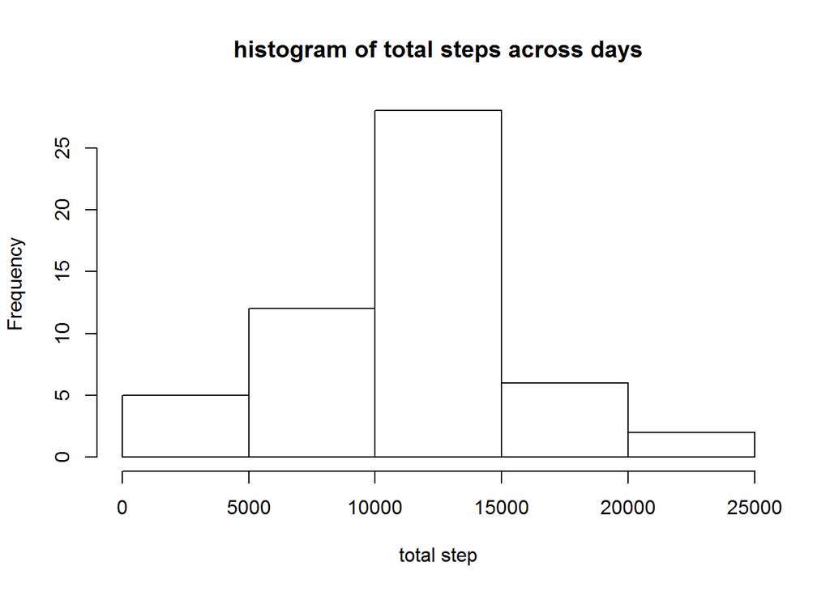

```r
pl<-hist(as.numeric(as.character(total_step$total_step)), main="histogram of total steps across days", xlab="total step")
```

3. Calculate and report the mean and median of the total number of steps taken per day

```r
mean(total_step$total_step, na.rm=T)
```

```
## [1] 10766.19
```

```r
median(total_step$total_step, na.rm=T)
```

```
## [1] 10765
```

# What is the average daily activity pattern?

1.Make a time series plot (i.e. type = “l”) of the 5-minute interval (x-axis) and the average number of steps taken, averaged across all days (y-axis)

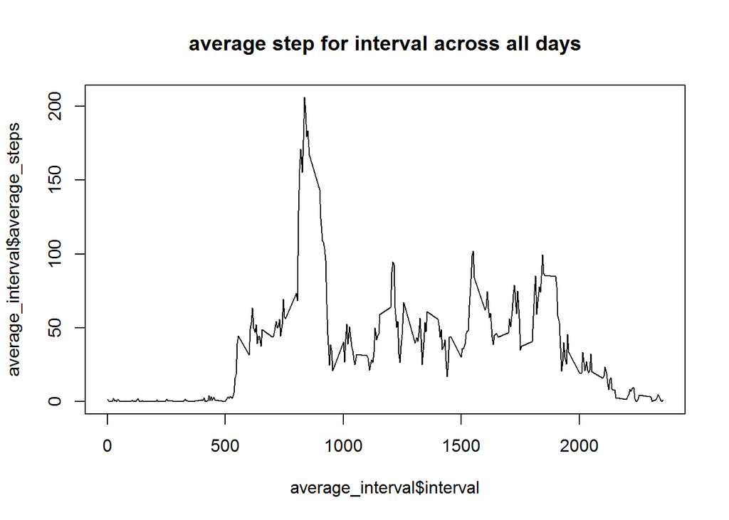

```r
average_interval<-aggregate(activity$steps ,list (activity$interval),FUN="mean",na.rm=T )
colnames(average_interval)<-c("interval", "average_steps")
plot(average_interval$interval,average_interval$average_steps,  type = "l", main="average step for interval across all days")
```

2.Which 5-minute interval, on average across all the days in the dataset, contains the maximum number of steps?

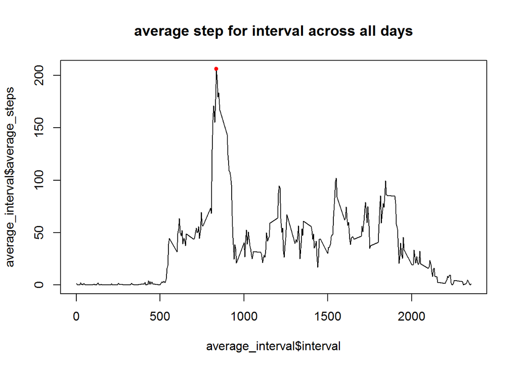

```r
plot(average_interval$interval,average_interval$average_steps,  type = "l", main="average step for interval across all days")
max_point<-average_interval[average_interval$average_steps==max(average_interval$average_steps),]
points(max_point, pch = 20, col='red')
```

```r
max_point
```

```
##     interval average_steps
## 104      835      206.1698
```

# Imputing missing values

1.Calculate and report the total number of missing values in the dataset (i.e. the total number of rows with NAs)

```r
nrow(activity[activity$steps=='NA',])
```

```
## [1] 2304
```

2.Devise a strategy for filling in all of the missing values in the dataset. The strategy does not need to be sophisticated. For example, you could use the mean/median for that day, or the mean for that 5-minute interval, etc.

The strategy I used is to calculate the daily average steps and applied to the missing values.

```r
mean_each_day<-aggregate(activity$steps ,list (activity$date),FUN="mean")
colnames(mean_each_day)<-c("date", "total_step")
mean(mean_each_day$total_step, na.rm=T)  --37.3826
```

```
## [1] 74.7652
```

```r
for(i in 1:ncol(mean_each_day)){
  mean_each_day[is.na(mean_each_day[,i]), i] <- mean(mean_each_day[,i], na.rm = TRUE)
}
missing_data<-activity[is.na(activity$steps),]
merge_data<-merge(missing_data,mean_each_day, by='date' )
no_missing_data<-na.omit(activity)
replace_data<-merge_data[,c(4,1,3)]
colnames(replace_data)<-colnames(activity)
```

3.Create a new dataset that is equal to the original dataset but with the missing data filled in.

```r
final_data<-rbind(no_missing_data,replace_data)
```

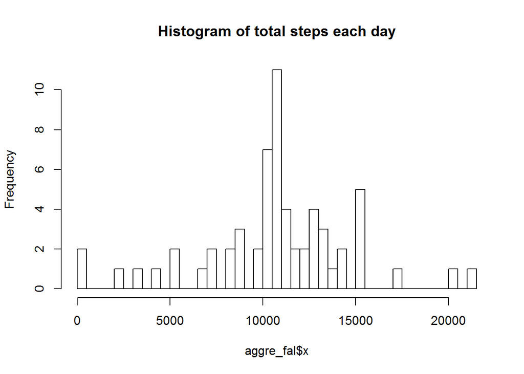

```r
aggre_fal<-aggregate(final_data$steps, list(final_data$date), FUN="sum")
hist(aggre_fal$x, breaks=50, main="Histogram of total steps each day")
```

```r
mean(aggre_fal$x)--10766.19
```

```
## [1] 21532.38
```

```r
median(aggre_fal$x)--10766.19
```

```
## [1] 21532.38
```